# Guide to the *ggplotplus* Package

### 8.1 Cautions and Limitations

This functionality is relatively new and highly experimental; its implementation will likely continue to change and develop in the short term. It will also depend on the continued development of the `ggrepel` package, upon which `direct_labels_plus()` depends.

More practically, though, this functionality only makes good sense to use in situations where a legend would otherwise be needed, groups aren’t already self-evident, there’s void space enough within the plotting area for sufficiently sized labels, the labels won’t overlap the data elements, and a standard coordinate system is being used.

While this can work with transformed data, it determines label locations on the data it’s provided, not on any transformed versions `ggplot2` might subsequently create. So, for example, if you intend to plot log-transformed y data, pre-transform them *before* providing them to `direct_labels_plus()`. Similarly, this will not work with `ggplot2::geom_smooth()` unless you provide fitted values from the smoothing function to `direct_labels_plus()`.

At present, this function is not designed to work with polygonal data elements, though such functionality might be added in the future. Similarly, this function does not yet work with `geom_ribbon()`, `geom_segment()`, or `geom_curve()` though it might in the future.

Notably, this function is not designed to work with non-standard coordinate systems like those produced by `coord_flip()` or `coord_polar()`, though you could possibly have success using it if you provide transformed data that make sense in the new coordinate systems.

If you are not initially able to get a satisfying configuration of labels, in particular because they are overlapping the data you’re trying to show/label, I recommend cycling through all available options for `placement`, as some might be more workable than others for a given graph. You may also consider adjusting the `size` parameter down or the `box.padding` parameter up (see `?ggrepel::geom_label_repel()` for details), but keep accessibility in mind as you do so. `adj_fact` can also be adjusted, similarly to `ggrepel::geom_label_repel()`’s `nudge_y` and `nudge_x`, to alter the target positions for labels in an attempt to place them more favorably. Lastly, consider raising the `force` value for `ggrepel::geom_label_repel()` to increase the intensity of the repulsion.

However, none of these options–nor this functionality overall–is guaranteed to work well in every case, especially when the density of data elements is high, the categories to label are numerous, and/or the volume of void space in the plotting is low. Discretion is advised!

## 9 Thoughtful Gridlines

One (arguably) controversial opinion coded into `ggplotplus`’s `theme_plus()` function is the total removal of **gridlines**. While some readers rely on them or expect them, many (probably the majority!) tend to find them distracting or visually cluttering in most situations. In fact, data viz experts often advise they not be used most of the time.

If you’d like to restore them, however, you can: you *could* manually add them using `theme_plus()`. It’ll let you! But there’s an easier (and more opinionated) option: `gridlines_plus()`. This function *selectively* reintroduces *only* the **major gridlines** (not minor ones) in *only* directions mapped to numeric variables (not discrete ones), and renders them as faintly as possible:

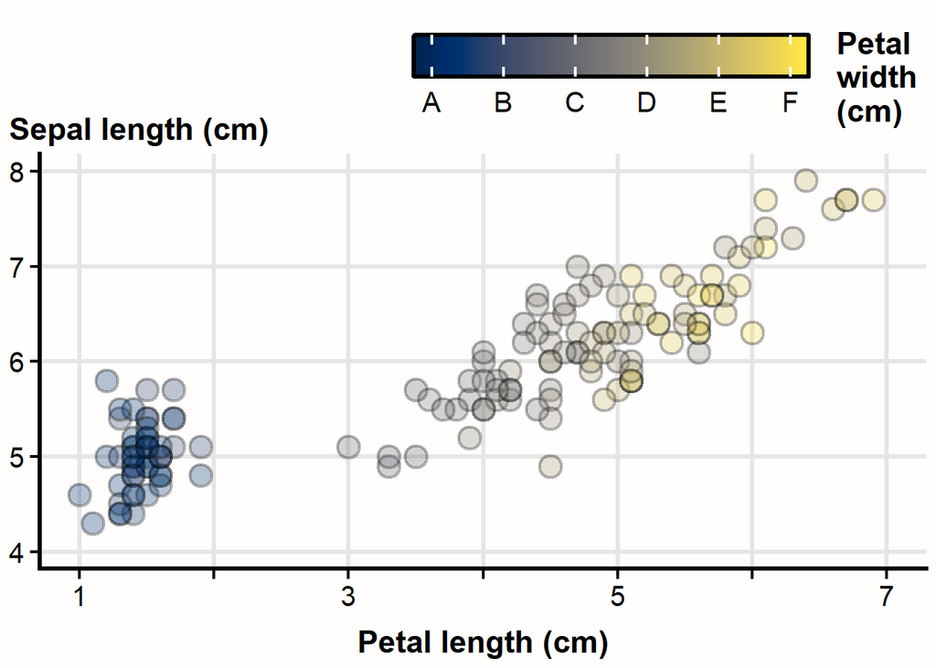

```r
ggplot(iris,
       mapping = aes(x = Petal.Length,
           y = Sepal.Length)) +
  geom_point(mapping = aes(fill = Petal.Width),
            alpha = 0.3) +
  theme_plus(begin_discrete = 0,
              end_discrete = 1) +
  scale_continuous_plus(scale = "x",
    name = "Petal length (cm)",
    thin.labels = TRUE) +
  scale_continuous_plus(scale = "y",
    name = "Sepal length (cm)") +
  scale_continuous_plus(scale = "fill",
    name = "Petal width (cm)",
    split_name = TRUE,
    labels = LETTERS[1:6]
    ) +
  yaxis_title_plus(nudgeTopLegendDown = TRUE) +
  gridlines_plus() #<--REINTRODUCE THOUGHTFUL GRIDLINES
```

These gridlines default to `"gray90"`. Prior research suggests gridlines this faint relative to the background color will be *just* visible *enough* for those who *need* them while being faint enough to easily fade into the background for everyone else.

However, if you want to tweak them in some respect or another, `gridlines_plus()` allows adjustments to `linetype`, `color`, and `linewidth` for your convenience—no need to use `theme_plus()` to make those types of adjustments!

If I had just one continuous axis, `gridlines_plus()` would automatically detect this and draw the gridlines in only the one relevant direction:

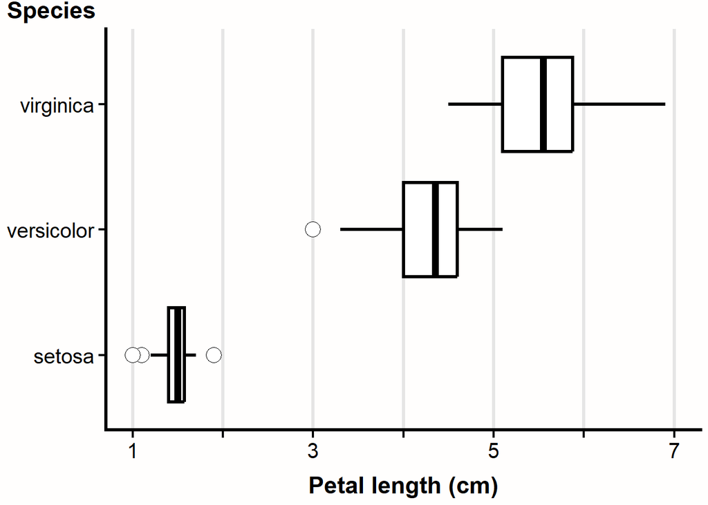

```r
ggplot(iris,
       mapping = aes(x = Petal.Length,
           y = Species)) + #<--MAKE DISCRETE
  geom_boxplot() + #<--CHANGE GEOM TYPE.
  scale_continuous_plus(
    scale = "x",
    name = "Petal length (cm)",
    thin.labels = TRUE) +
  theme_plus() +
  yaxis_title_plus() +
  gridlines_plus()
```

Because gridlines are *primarily* beneficial for helping a reader discern exact values, there’s no need for them when an axis is discrete and thus has no exact values to read! Thus, the presentation is simplified by omitting them in that direction automatically.

### 9.1 Selectively Not Adding Gridlines

There might be situations wherein you might want to add very subtle gridlines, and you have more than one continuous axis, but you already know you don’t want to add gridlines along one of those two axes. For example, perhaps you have time data on the x-axis, and, even though these data are technically continuous, you don’t want gridlines added along that dimension. No worries: set the `notx` or `noty` parameter inside `gridlines_plus()` to `TRUE`:

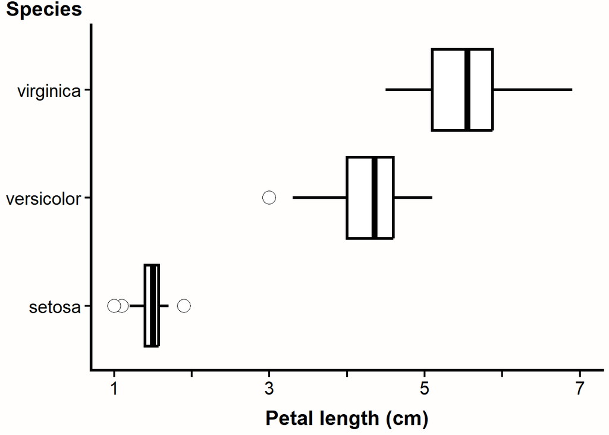

```r
ggplot(iris,
       mapping = aes(x = Petal.Length,
           y = Species)) +
  geom_boxplot() +
  scale_continuous_plus(
    scale = "x",
    name = "Petal length (cm)",
    thin.labels = TRUE) +
  theme_plus() +
  yaxis_title_plus() +
  gridlines_plus(notx = TRUE) #<--REJECT GRIDLINES ALONG THIS SCALE
```

In this case, this functionally represses all gridlines because there is no other continuous axis.

## 10 Faceting With `ggplotplus`

Faceting—splitting a plot into **small multiples** based on one or more discrete variables—is a core `ggplot2` feature, and it *generally* works with the tools provided by `ggplotplus`:

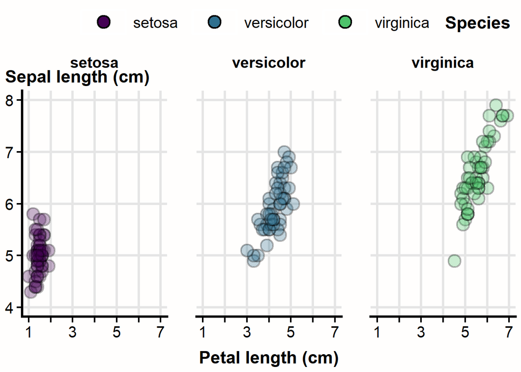

```r
#EXAMPLE GRAPH TO SHOW FACETING FEATURES:
ggplot(iris,
       mapping = aes(x = Petal.Length,
           y = Sepal.Length)) +
  geom_point(mapping = aes(fill = Species),
            alpha = 0.3) +
  scale_continuous_plus(
    scale = "x",
    name = "Petal length (cm)",
    thin.labels = TRUE) +
  scale_continuous_plus(
    scale = "y",
    name = "Sepal length (cm)") +
  theme_plus() +
  yaxis_title_plus() +
  gridlines_plus() +
  facet_grid(. ~ Species) #<--MAKE ONE SMALL MULTIPLE (PANEL) PER SPECIES (ACROSS COLUMNS)
```

As this example shows, **many features in `ggplotplus` are compatible with faceting**, though some *may* require some thought.

For example, using `yaxis_title_plus()` with facets works—the function places the relocated y-axis title below the facet strip labels. However, for some, this could look a little confusing or awkward. In general, I don’t recommend using `yaxis_title_plus()` when you’re faceting and have the facet strip labels at the top of the plot.

However, there are three potential workarounds. The first is simply to facet by rows instead of columns:

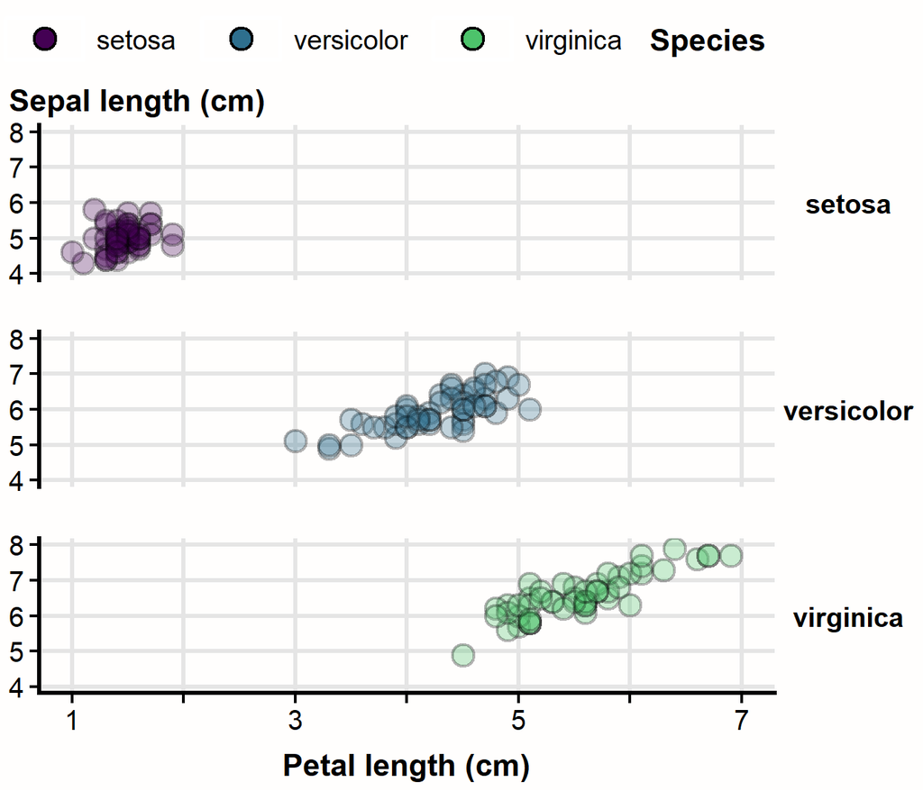

```r
###INCREASE THE FIGURE HEIGHT A LITTLE TO MAKE ROOM.
ggplot(iris,
       mapping = aes(x = Petal.Length,
           y = Sepal.Length)) +
  geom_point(mapping = aes(fill = Species),
            alpha = 0.3) +
  scale_continuous_plus(
    scale = "x",
    name = "Petal length (cm)",
    thin.labels = TRUE) +
  scale_continuous_plus(
    scale = "y",
    name = "Sepal length (cm)") +
  theme_plus() +
  yaxis_title_plus() +
  gridlines_plus() +
  facet_grid(Species ~ .) #<--FACET ACROSS ROWS INSTEAD.
```

Another option would be to relocate the facet strip labels to the bottom of the graph so they aren’t competing with the relocated y-axis title for space:

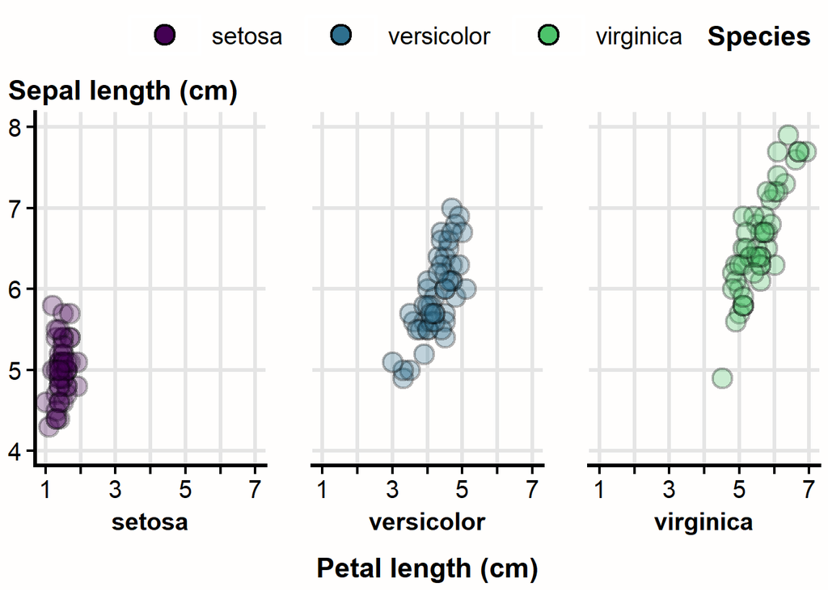

```r
ggplot(iris,
       mapping = aes(x = Petal.Length,
           y = Sepal.Length)) +
  geom_point(mapping = aes(fill = Species),
            alpha = 0.3) +
  scale_continuous_plus(
    scale = "x",
    name = "Petal length (cm)",
    thin.labels = TRUE) +
  scale_continuous_plus(
    scale = "y",
    name = "Sepal length (cm)") +
  theme_plus() +
  yaxis_title_plus() +
  gridlines_plus() +
  facet_grid(. ~ Species,
             switch = "x") #<--MOVE STRIP LABELS TO BOTTOM.
```

This honestly works better in some ways anyhow!

A third option would be to suppress the facet strip labels and instead only retain the legend, since I’m mapping `Species` here to both panel and color redundantly:

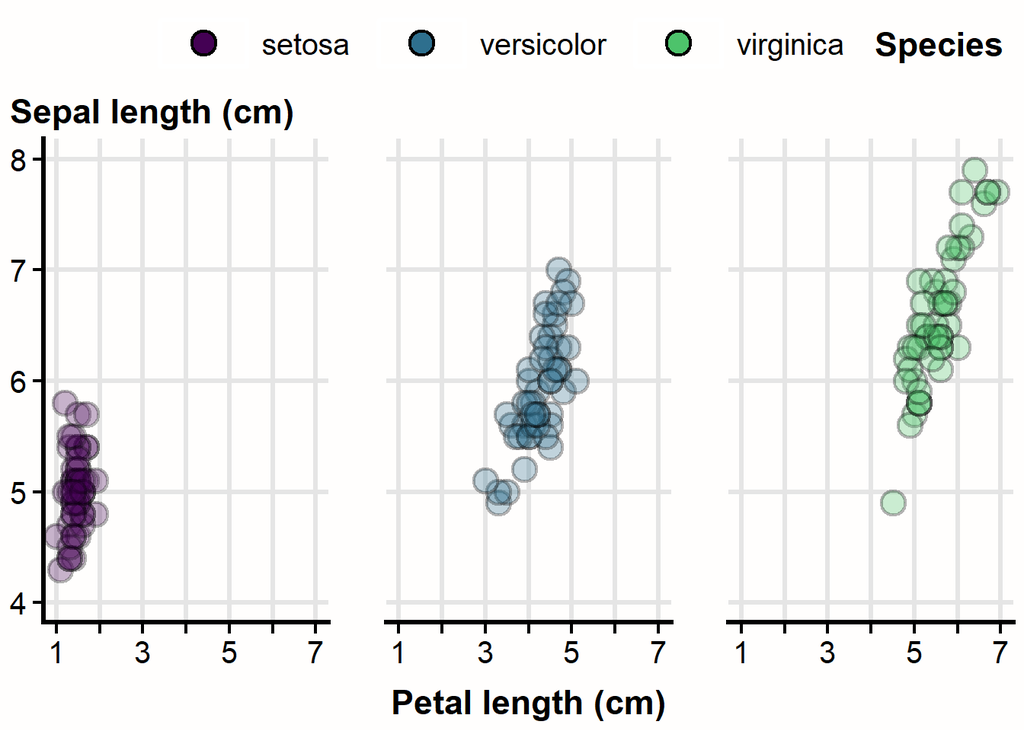

```r
ggplot(iris,
       mapping = aes(x = Petal.Length,
           y = Sepal.Length)) +
  geom_point(mapping = aes(fill = Species),
            alpha = 0.3) +
  theme_plus(strip.text = element_blank()) +
  scale_continuous_plus(
    scale = "x",
    name = "Petal length (cm)",
    thin.labels = TRUE) +
  scale_continuous_plus(
    scale = "y",
    name = "Sepal length (cm)") +
  yaxis_title_plus() +
  gridlines_plus() +
  facet_grid(. ~ Species)
```

Faceting is a relatively complex feature of `ggplot2`. `ggplotplus`’s features are mostly designed to work with it, but that doesn’t mean some creativity and future improvements won’t be involved!

## 11 Using Various Aesthetics to Draw Focus

Many graph design guides encourage designers to ensure the message of their graphs is clear: “*Here* is what you should be looking for/comparing in this graph.” This can sometimes be a challenge, especially when the data are messy or there’s a lot of them and also some obligation to show them all anyway for transparency or comparison purposes.

In these instances, chroma (grayness vs “pureness”) can be a useful visual channel (when used thoughtfully) to draw a reader’s attention to one or more subsets of the data while retaining but visually de-emphasizing the rest. Saturated colors tend to naturally draw our eye while gray, muted colors fade naturally into the background. While using color in this way in `ggplot2` is not overly difficult, it does require some solid understanding of the package’s underlying systems.

`scale_focus_plus()` is a wrapper of `ggplot2`’s `scale_fill/colour_manual()` functions that makes putting a graph into “focus mode” approachable. Returning to our scatterplot from earlier:

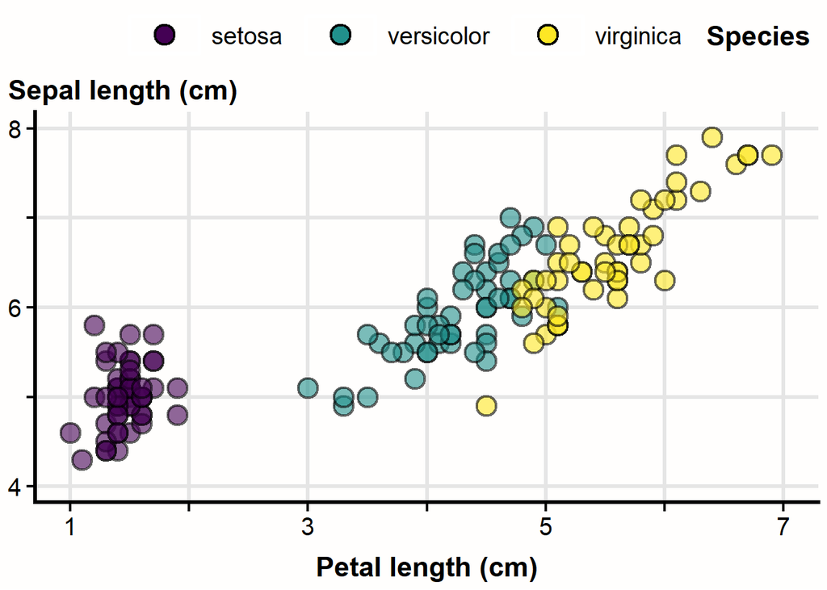

```r
ggplot(iris,
       mapping = aes(x = Petal.Length,
                     y = Sepal.Length)) +
  geom_point(mapping = aes(fill = Species),
             alpha = 0.6) +
  theme_plus(begin_discrete = 0,
             end_discrete = 1) +
  scale_continuous_plus(scale = "x",
                        name = "Petal length (cm)",
                        thin.labels = TRUE) +
  scale_continuous_plus(scale = "y",
                        name = "Sepal length (cm)",
                        thin.labels = TRUE) +
  gridlines_plus() +
  yaxis_title_plus()
```

We could ask: What if we wanted the reader to focus on just one species here? Or perhaps the comparison between two species? `scale_focus_plus()` makes generating a version that facilitates that purpose simple:

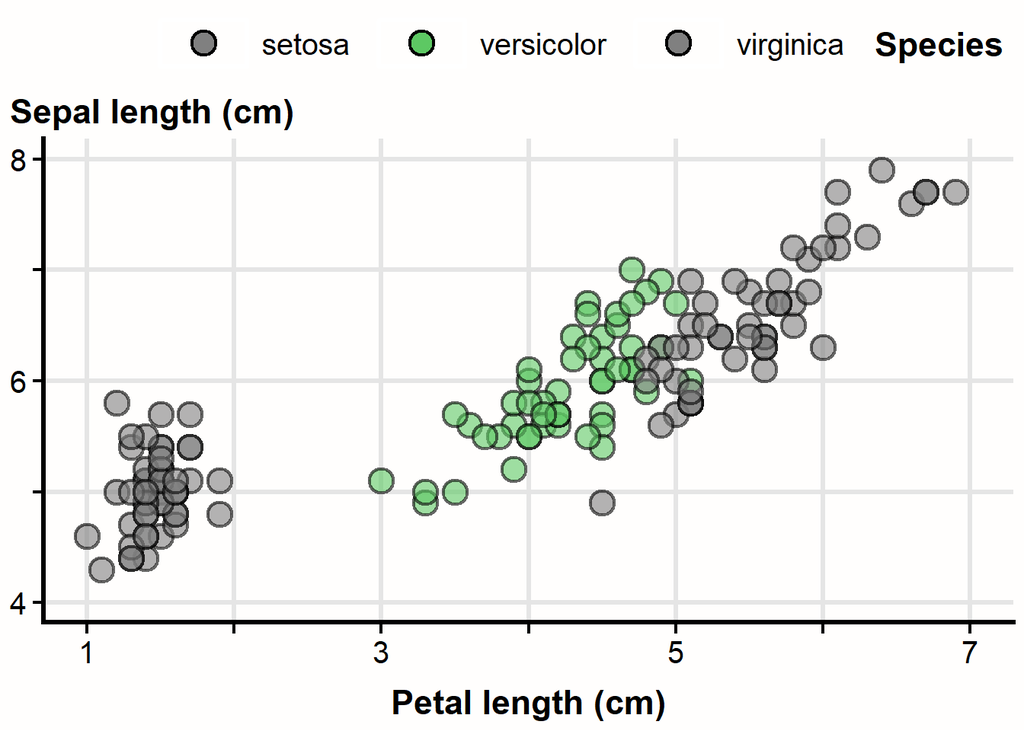

```r
ggplot(iris,
       mapping = aes(x = Petal.Length,
                     y = Sepal.Length)) +
  geom_point(mapping = aes(fill = Species),
             alpha = 0.6) +
  theme_plus(begin_discrete = 0,
             end_discrete = 1) +
  scale_continuous_plus(scale = "x",
                        name = "Petal length (cm)",
                        thin.labels = TRUE) +
  scale_continuous_plus(scale = "y",
                        name = "Sepal length (cm)",
                        thin.labels = TRUE) +
  gridlines_plus() +
  yaxis_title_plus() +
  scale_focus_plus(aes = "fill", #<--ARE WE USING COLOR OR FILL TO DRAW FOCUS?
                   group_var = iris$Species, #THE DISCRETE VARIABLE DETERMINING THE GROUPS
                   focal_groups = "versicolor" #THE GROUP(S) TO DRAW FOCUS TO
                   )
```

In this version, our eyes are immediately drawn to the `versicolor` group.

We can pass instructions through to `ggplot2::scale_fill_manual()` here, if we’d like, such as custom legend labels and a legend title:

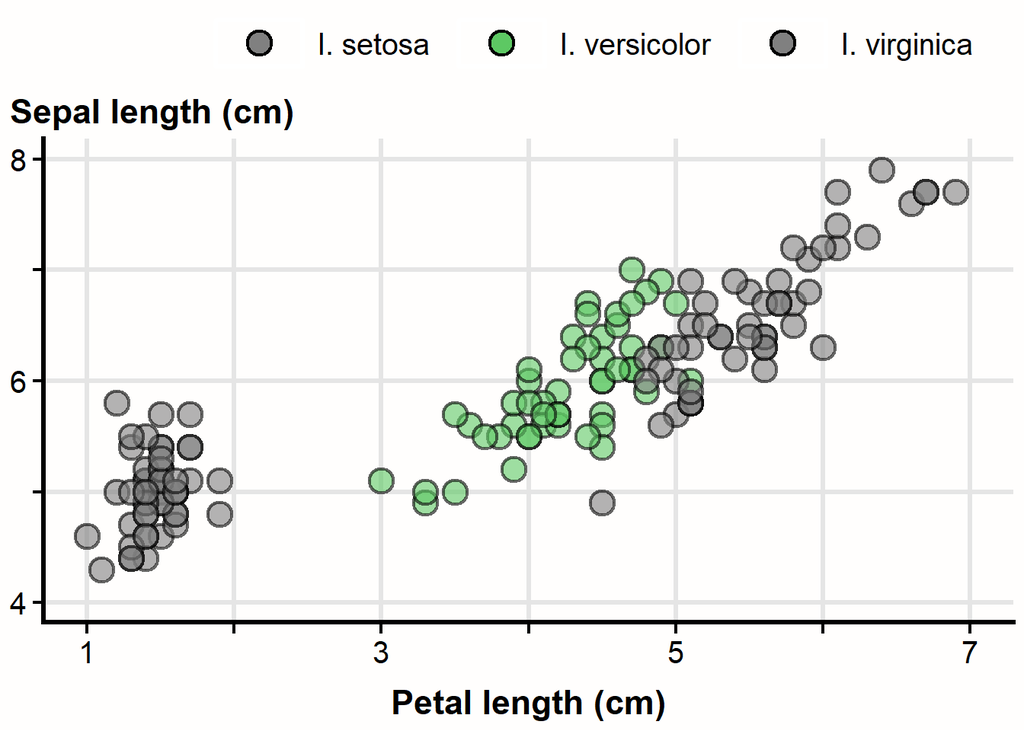

```r
ggplot(iris,
       mapping = aes(x = Petal.Length,
                     y = Sepal.Length)) +
  geom_point(mapping = aes(fill = Species),
             alpha = 0.6) +
  theme_plus(begin_discrete = 0,
             end_discrete = 1) +
  scale_continuous_plus(scale = "x",
                        name = "Petal length (cm)",
                        thin.labels = TRUE) +
  scale_continuous_plus(scale = "y",
                        name = "Sepal length (cm)",
                        thin.labels = TRUE) +
  gridlines_plus() +
  yaxis_title_plus() +
  scale_focus_plus(aes = "fill",
                   group_var = iris$Species,
                   focal_groups = "versicolor",
                   labels = c("I. setosa", "I. versicolor", "I. virginica"), #<--REPLACE LABELS
                   name = "" #<--BLANK LEGEND TITLE.
  )
```

`guide = "none"` would eliminate the legend entirely, which could be appropriate in graphs where a different visual channel is already communicating group differences (e.g., a bar plot where the x axis does this).

By default, non-focal groups are not differentiated from each other. This is also ok in instances where another visual channel differentiates them (or when identifying distinct, non-focal groups is unnecessary). However, if you want to ensure they’re differentiated, set `diff_nonfocal` to `TRUE`:

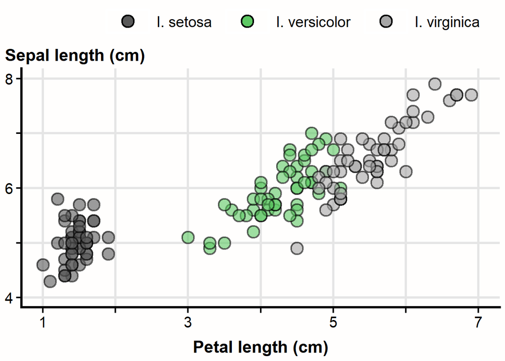

```r
ggplot(iris,
       mapping = aes(x = Petal.Length,
                     y = Sepal.Length)) +
  geom_point(mapping = aes(fill = Species),
             alpha = 0.6) +
  theme_plus(begin_discrete = 0,
             end_discrete = 1) +
  scale_continuous_plus(scale = "x",
                        name = "Petal length (cm)",
                        thin.labels = TRUE) +
  scale_continuous_plus(scale = "y",
                        name = "Sepal length (cm)",
                        thin.labels = TRUE) +
  gridlines_plus() +
  yaxis_title_plus() +
  scale_focus_plus(aes = "fill",
                   group_var = iris$Species,
                   focal_groups = "versicolor",
                   labels = c("I. setosa", "I. versicolor", "I. virginica"),
                   name = "",
                   diff_nonfocal = TRUE #<--USE DIFFERENT SHADES FOR THE DIFFERENT NON-FOCAL GROUPS.
  )
```

This allows you to create “focus mode” versions of plots that would still be accessible in grayscale or for those with color-vision impairments, so long as you maintain the variance in lightness that the function strives for.

You can focal more than one group, and you can provide custom colors for each of these if you prefer:

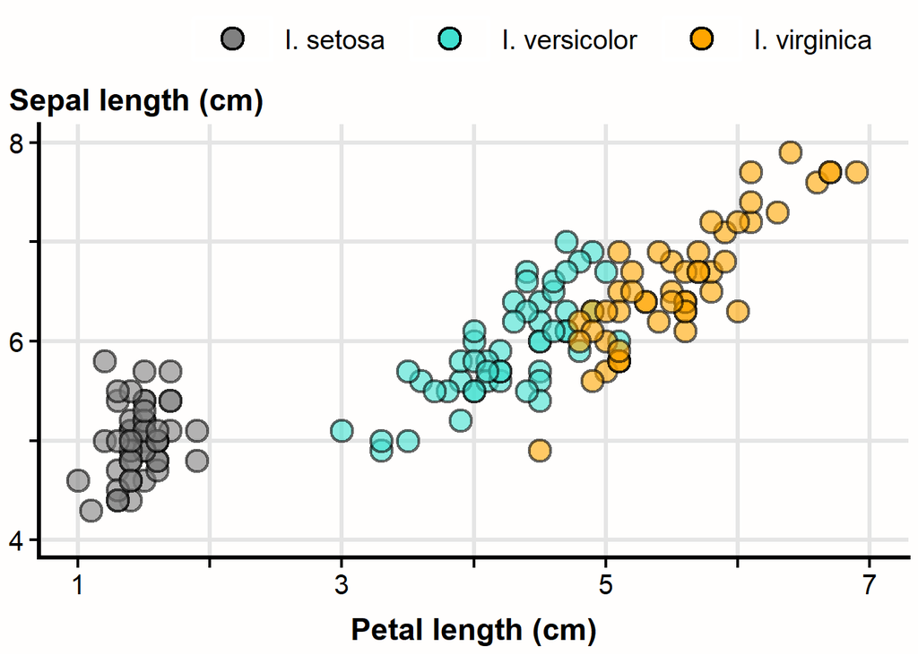

```r
ggplot(iris,
       mapping = aes(x = Petal.Length,
                     y = Sepal.Length)) +
  geom_point(mapping = aes(fill = Species),
             alpha = 0.6) +
  theme_plus(begin_discrete = 0,
             end_discrete = 1) +
  scale_continuous_plus(scale = "x",
                        name = "Petal length (cm)",
                        thin.labels = TRUE) +
  scale_continuous_plus(scale = "y",
                        name = "Sepal length (cm)",
                        thin.labels = TRUE) +
  gridlines_plus() +
  yaxis_title_plus() +
  scale_focus_plus(aes = "fill",
                   group_var = iris$Species,
                   focal_groups = c("versicolor", "virginica"), #<--MAKE THIS A VECTOR AND ADD ALL GROUPS
                   labels = c("I. setosa", "I. versicolor", "I. virginica"),
                   name = "",
                   custom_focal = c("versicolor" = "turquoise", "virginica" = "orange") #<--A NAMED VECTOR LINKS COLORS TO VALUES.
  )
```

`scale_focus_plus()` also now controls `ggplot2`’s `alpha`, `size`, `linewidth` aesthetics via its `aes` argument. Larger points, thicker lines, and more opaque geometries will all tend to draw visual focus in much the same way as high-chroma colors do and could be superior to chroma in many situations.

### 11.1 Cautions and limitations

At present, `scale_focus_plus()` does not interact with the package’s coaching messages system. As such, you may receive coaching messages that `scale_focus_plus()` is somehow addressing–feel free to ignore or disable these if that happens.

Also, `scale_focus_plus()` is designed to work with discrete (categorical) data only. However, continuous data could be binned into discrete categories to make them compatible; see `?scale_focus_plus()` for details and an example.

## 12 Color Isn’t Everything! Incorporating Distinctive Shapes Into Scatterplots

Thus far, this guide has mostly focused on graphs that use color (hue, lightness, and chroma) to communicate differences in the data. `ggplotplus` is designed to revamp how `ggplot2` approaches color to yield graphs that are more accessible and more interpretable while still having the aesthetic and engagement benefits of color.

However, *any* graph that uses color to communicate difference can only be *so* accessible and interpretable. A small but sizable number of humans are completely colorblind, and color perception weakens as we age. Additionally, many people still read and/or view graphs in contexts wherein colors may not be readily distinguished.

As such, data viz advocates would remind us all there are other **visual channels** (ways of communicating difference in a graph) beyond color available to us, including many already baked into `ggplot2`!

One of these, point `shape`, is a useful and classic channel for communicating difference in scatterplots like those in the guide so far.

However, `ggplot2` only makes available the same 26 shapes available in base R:

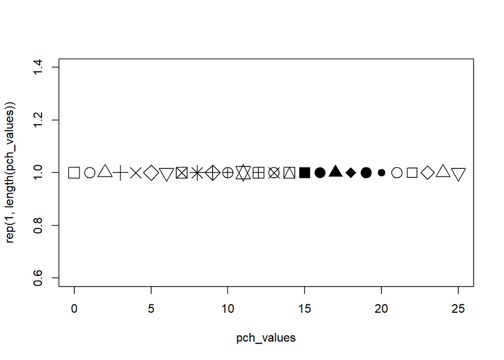

```r
pch_values = 0:25

#THE SHAPES AVAILABLE IN R/GGPLOT2
plot(pch_values,
     rep(1, length(pch_values)),
     pch = 0:25, cex = 2)
```

While there is certainly *some* variation between these shapes, many are perceptually similar, making them difficult to distinguish quickly: Research has suggested that humans more readily distinguish shapes when they vary strongly from each other along three axes:

1. Openness (how “full” or “empty” they are)
2. Spikiness (how “pointy” and “angular” they are versus how “rounded” they are) and
3. Intersectionality (how “crossed,” if at all, their interior elements are)

Notably, only the last five shapes of those bundled with R have separate outline (stroke) and interior (fill) channels, allowing them to bear separate outline and fill colors, and those same five shapes are also relatively similar with respect to openness and intersectionality, making them harder to distinguish from each other. This limits the versatility of this visual channel.

As such, `ggplotplus` introduces `geom_point_plus()`, a variant of `ggplot2`’s `geom_point()` layer that introduces access to nine new, intentionally crafted shapes that vary as much as possible along the three axes described above while also being able to bear separate stroke and fill colors:

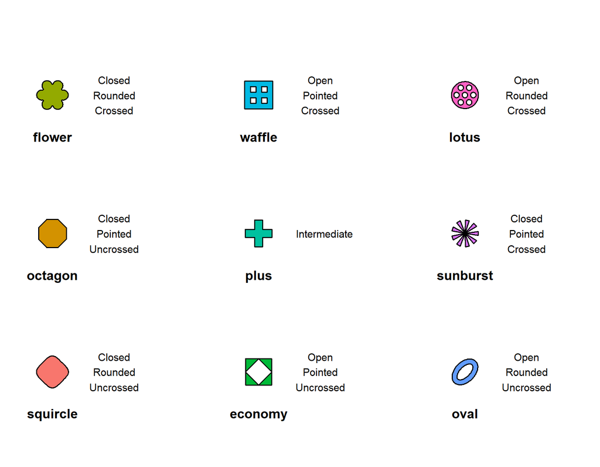

```r
geom_point_plus_shapes()
```

These shapes can be used to communicate difference whenever using color (alone) might be undesirable, insufficient, and/or unnecessary:

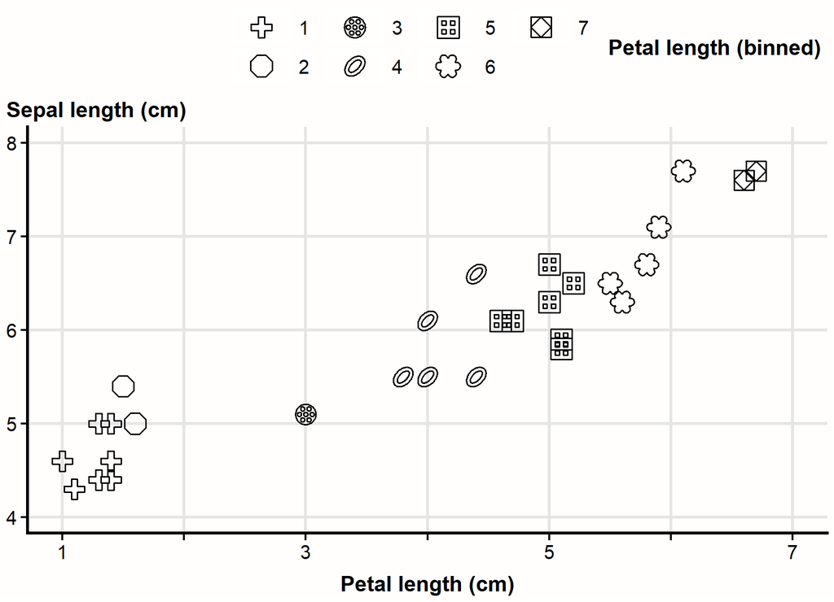

```r
set.seed(123)

ggplot(
  iris[sample(1:nrow(iris), 30, replace = FALSE), ], #<--RESTRICT DATA VOLUME TO REDUCE OVERPLOTTING FOR ILLUSTRATION.
  mapping = aes(x = Petal.Length, y = Sepal.Length)
) +
  geom_point_plus(
    mapping = aes(shape = factor(round(Petal.Length))), #<--MAP SHAPE TO ANY CATEGORICAL VARIABLE WITH 9 OR FEWER LEVELS!
    legend_title = "Petal length (binned)"
  ) + #<--SPECIFY NEW LEGEND TITLE HERE FOR CONVENIENCE.
  scale_continuous_plus(scale = "x",
                        name = "Petal length (cm)",
                        thin.labels = TRUE) +
  scale_continuous_plus(scale = "y",
                        name = "Sepal length (cm)") +
  theme_plus() +
  yaxis_title_plus() +
  gridlines_plus()
```

As the example above shows, you can specify a new shape legend title inside `geom_point_plus()` using the `legend_title` parameter for convenience. You can also use the `chosen_shapes` parameter to specify which exact shapes from the new palette you want to use:

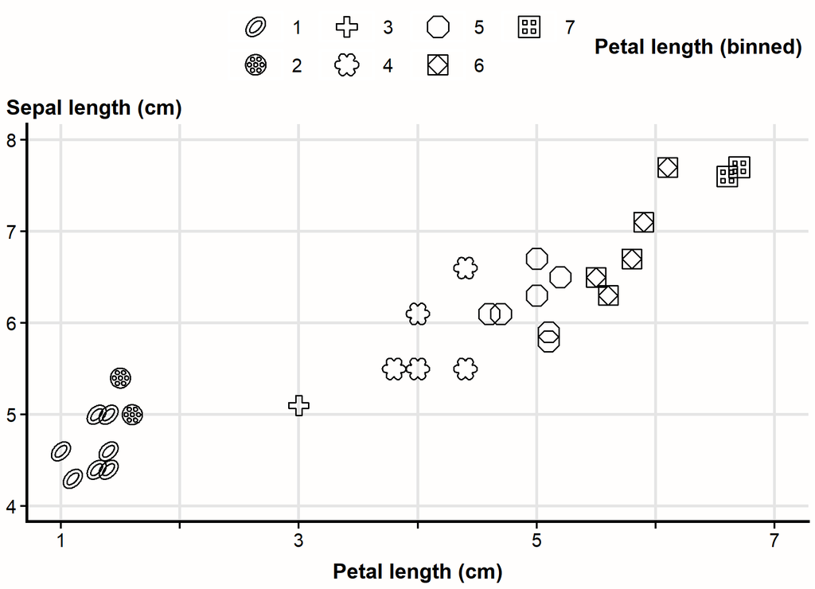

```r
set.seed(123)

ggplot(
  iris[sample(1:nrow(iris), 30, replace = FALSE), ],
  mapping = aes(x = Petal.Length, y = Sepal.Length)
) +
  geom_point_plus(
    mapping = aes(shape = factor(round(Petal.Length))),
    legend_title = "Petal length (binned)",
    chosen_shapes = c("oval", "lotus", "plus", "flower", "octagon", "economy", "waffle") #<--SPECIFY SPECIFIC SHAPES YOU WANT.
  ) +
  scale_continuous_plus(scale = "x",
                        name = "Petal length (cm)",
                        thin.labels = TRUE) +
  scale_continuous_plus(scale = "y",
                        name = "Sepal length (cm)") +
  theme_plus() +
  yaxis_title_plus() +
  gridlines_plus()
```

As previously noted, all these shapes have separate fill and color aesthetics, so these color-based aesthetics can be set to constants or even mapped to variables (although I wouldn’t necessarily recommend doing the latter in many cases):

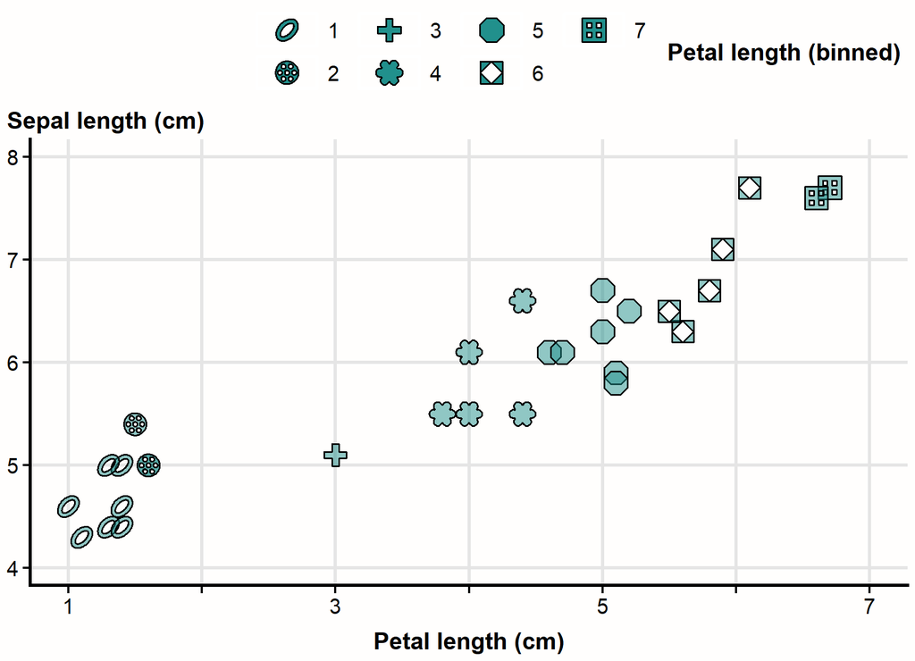

```r
set.seed(123)

ggplot(
  iris[sample(1:nrow(iris), 30, replace = FALSE), ],
  mapping = aes(x = Petal.Length, y = Sepal.Length)
) +
  geom_point_plus(
    mapping = aes(shape = factor(round(Petal.Length))),
    legend_title = "Petal length (binned)",
    chosen_shapes = c("oval", "lotus", "plus", "flower", "octagon", "economy", "waffle"),
    fill = viridis::viridis(1,0.5,0.5) #<--GO AHEAD, MAP COLOR/FILL TO CONSTANTS OR EVEN TO VARIABLES!
  ) +
  scale_continuous_plus(scale = "x",
                        name = "Petal length (cm)",
                        thin.labels = TRUE) +
  scale_continuous_plus(scale = "y",
                        name = "Sepal length (cm)") +
  theme_plus() +
  yaxis_title_plus() +
  gridlines_plus()
```

There is also a `geom_jitter_plus()`, if you’d like to add a little variance to your point locations, e.g., to reduce overplotting:

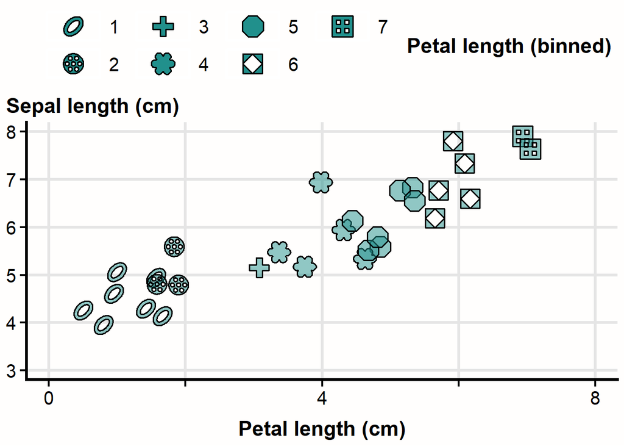

```r
set.seed(123)

ggplot(
  iris[sample(1:nrow(iris), 30, replace = FALSE), ],
  mapping = aes(x = Petal.Length, y = Sepal.Length)
) +
  geom_jitter_plus(
    mapping = aes(shape = factor(round(Petal.Length))),
    legend_title = "Petal length (binned)",
    chosen_shapes = c("oval", "lotus", "plus", "flower", "octagon", "economy", "waffle"),
    fill = viridis::viridis(1,0.5,0.5),
    width = 0.5, #<--USE WIDTH, HEIGHT, AND SEED TO CONTROL THE JITTERING.
    height = 0.35,
  ) +
  scale_continuous_plus(scale = "x",
                        name = "Petal length (cm)",
                        thin.labels = TRUE) +
  scale_continuous_plus(scale = "y",
                        name = "Sepal length (cm)") +
  theme_plus() +
  yaxis_title_plus() +
  gridlines_plus()
```

Note that, at present, `shape` cannot be mapped globally to access these shapes–it must be mapped locally in `geom_point_plus()`. Functionality to access these points in different ways and geoms may be added in the future.

### 12.1 Using a Mixture of R and `ggplotplus` Shapes

To respect the legacy of R graphics, `geom_point_plus()` also has access to the five base R shapes (`pch` 21:25) that can take both fill and color aesthetics. These are accessible via their standard `pch` numbers, e.g. 23, or by names: “circle”, “square”, “diamond”, “triangle_up”, and “triangle_down”. These can be mix-and-matched with the other shapes added by `ggplotplus`:

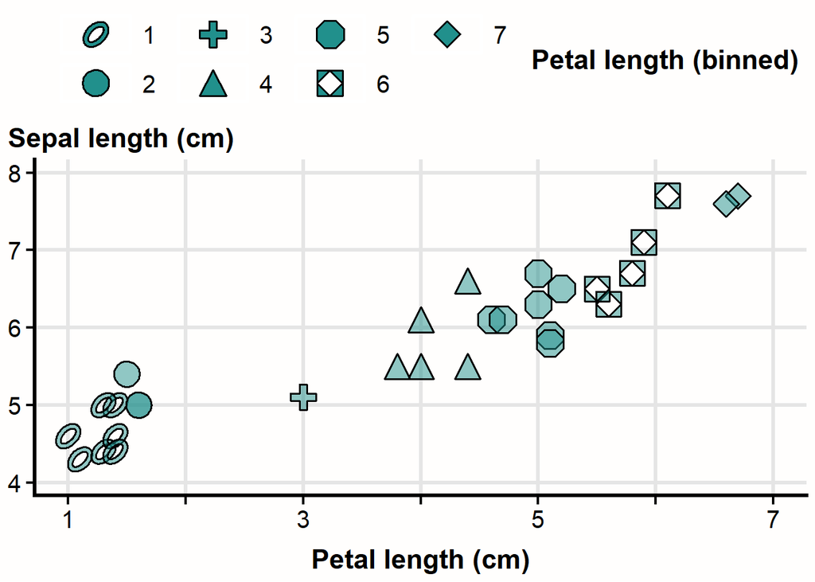

```r
set.seed(123)

ggplot(
  iris[sample(1:nrow(iris), 30, replace = FALSE), ],
  mapping = aes(x = Petal.Length, y = Sepal.Length)
) +
  geom_point_plus(
    mapping = aes(shape = factor(round(Petal.Length))),
    legend_title = "Petal length (binned)",
    chosen_shapes = c("oval", "21", "plus", "triangle_up", "octagon", "economy", "diamond"), #<--YOU CAN ACCESS BASE R SHAPES 21-25 VIA NAME OR NUMBER
    fill = viridis::viridis(1,0.5,0.5)
  ) +
  scale_continuous_plus(scale = "x",
                        name = "Petal length (cm)",
                        thin.labels = TRUE) +
  scale_continuous_plus(scale = "y",
                        name = "Sepal length (cm)") +
  theme_plus() +
  yaxis_title_plus() +
  gridlines_plus()
```

### 12.2 Adding New Shapes to `ggplotplus` For a Session

More radically, you can add your own shapes for use in scatterplots!

For example, a basic 5-pointed star, with no holes, might have coordinates like these:

```r
(test_star = data.frame(
  x = c(
    0.000,
    0.118,
    0.380,
    0.190,
    0.235,
    0.000,
    -0.235,
    -0.190,
    -0.380,
    -0.118
  ),
  y = c(
    0.400,
    0.124,
    0.124,
    -0.047,
    -0.324,
    -0.153,
    -0.324,
    -0.047,
    0.124,
    0.124
  ),
  piece = 1
))
```

| x | y | piece |
| --- | --- | --- |
| 0.000 | 0.400 | 1 |
| 0.118 | 0.124 | 1 |
| 0.380 | 0.124 | 1 |
| 0.190 | -0.047 | 1 |
| 0.235 | -0.324 | 1 |
| 0.000 | -0.153 | 1 |
| -0.235 | -0.324 | 1 |
| -0.190 | -0.047 | 1 |
| -0.380 | 0.124 | 1 |
| -0.118 | 0.124 | 1 |

I can register this shape with `ggplotplus` for the session using `add_shape_plus()`:

```r
add_shape_plus(name = "star", #<--THE NAME TO USE TO ACCESS THIS SHAPE.
               shape = test_star
              )
```

Once registered, you can refer to this shape by name in any later calls:

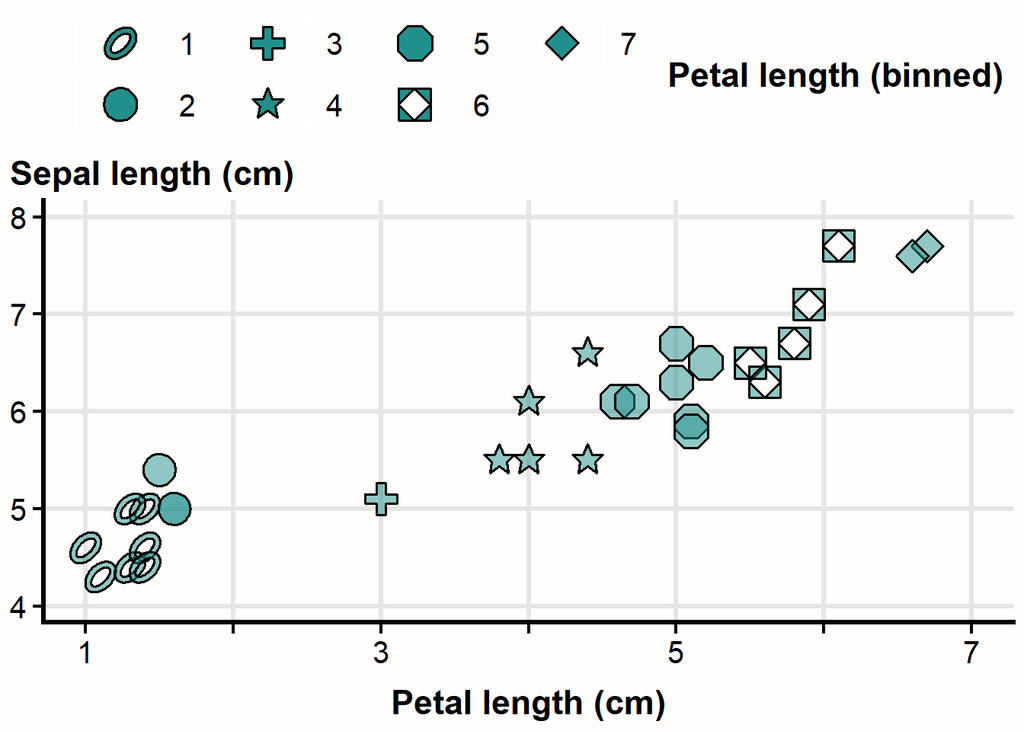

```r
set.seed(123)

ggplot(
  iris[sample(1:nrow(iris), 30, replace = FALSE), ],
  mapping = aes(x = Petal.Length, y = Sepal.Length)
) +
  geom_point_plus(
    mapping = aes(shape = factor(round(Petal.Length))),
    legend_title = "Petal length (binned)",
    chosen_shapes = c("oval", "21", "plus", "star", "octagon", "economy", "diamond"), #<--YOU CAN NOW ACCESS THE STAR SHAPE, IF IT'S BEEN REGISTERED
    fill = viridis::viridis(1,0.5,0.5)
  ) +
  scale_continuous_plus(scale = "x",
                        name = "Petal length (cm)",
                        thin.labels = TRUE) +
  scale_continuous_plus(scale = "y",
                        name = "Sepal length (cm)") +
  theme_plus() +
  yaxis_title_plus() +
  gridlines_plus()
```

Feel free to get creative to make highly distinctive shapes! Generative AI models are, in my experience, very good at turning shape ideas into compatible lists of vertices and holes, if given the parameters described above.

Note that shape registrations last only for the session; you will need to re-register shapes each new session.

## 13 More Unusual Interactions

One sort of strange function in `ggplot2` is `coord_flip()`, which flips the graph’s coordinate system so that the x axis runs vertically and the y axis runs horizontally (it should be noted that this function is now deprecated in `ggplot2` Version 4). `ggplotplus`’s tools try to work with this function, if you use it:

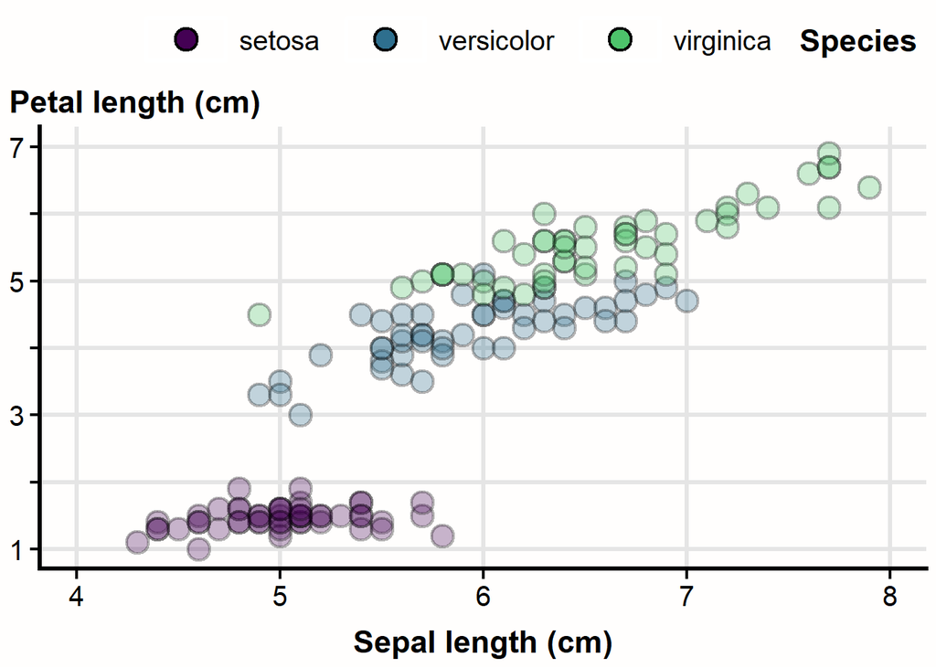

```r
ggplot(iris,
       mapping = aes(x = Petal.Length,
           y = Sepal.Length)) +
  geom_point(mapping = aes(fill = Species),
            alpha = 0.3) +
  scale_continuous_plus(
    scale = "x",
    name = "Petal length (cm)",
    thin.labels = TRUE) +
  scale_continuous_plus(
    scale = "y",
    name = "Sepal length (cm)") +
  theme_plus() +
  yaxis_title_plus() +
  gridlines_plus() +
  coord_flip() #<--CHECK THIS OUT--THE Y AXIS TITLE IS REALLY THE X AXIS TITLE!
```

## 14 Final scatterplot for reference

Here’s a “final” version of the scatterplot using (almost) all of `ggplotplus`’s tools together:

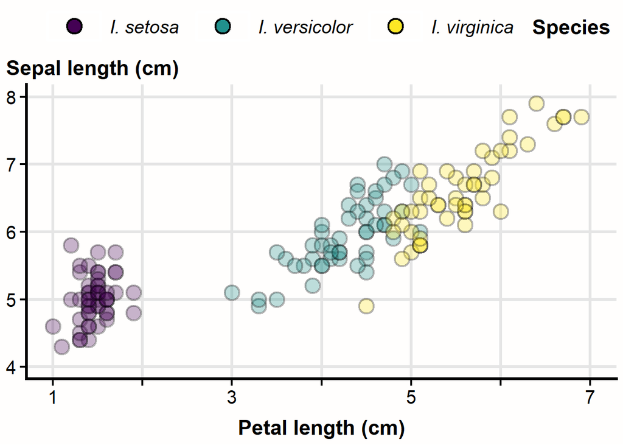

```r
ggplot(iris,
       mapping = aes(x = Petal.Length,
           y = Sepal.Length)) +
  geom_point(mapping = aes(fill = Species),
            alpha = 0.3) +
  scale_continuous_plus(
    scale = "x",
    name = "Petal length (cm)",
    thin.labels = TRUE) +
  scale_continuous_plus(
    scale = "y",
    name = "Sepal length (cm)") +
  scale_fill_discrete(
    labels = c("I. setosa", "I. versicolor", "I. virginica")
  ) +
  theme_plus(
    legend.text = element_text(face = "italic"),#<--MAKE THE TAXON NAMES ITALIC LIKE THEY OUGHT TO BE!
    begin_discrete = 0,
    end_discrete = 1) +
  yaxis_title_plus() +
  gridlines_plus()
```

I’d say that looks pretty nice, but it’s, at *worst*, an evidence-based starting point upon which to build something truly impactful and distinctive!

## 15 (EXPERIMENTAL) Icon Arrays

Good research suggests that one data type that many people struggle with is frequencies (i.e., the rates at which phenomena are observed). For example, for many, a 12% risk is difficult to reason about and to put into perspective. For these people, seeing that rate expressed in a bar graph or, worse, a pie chart, is often little help.

For these people and many others, one visualization that has shown great promise is called an **icon array**:

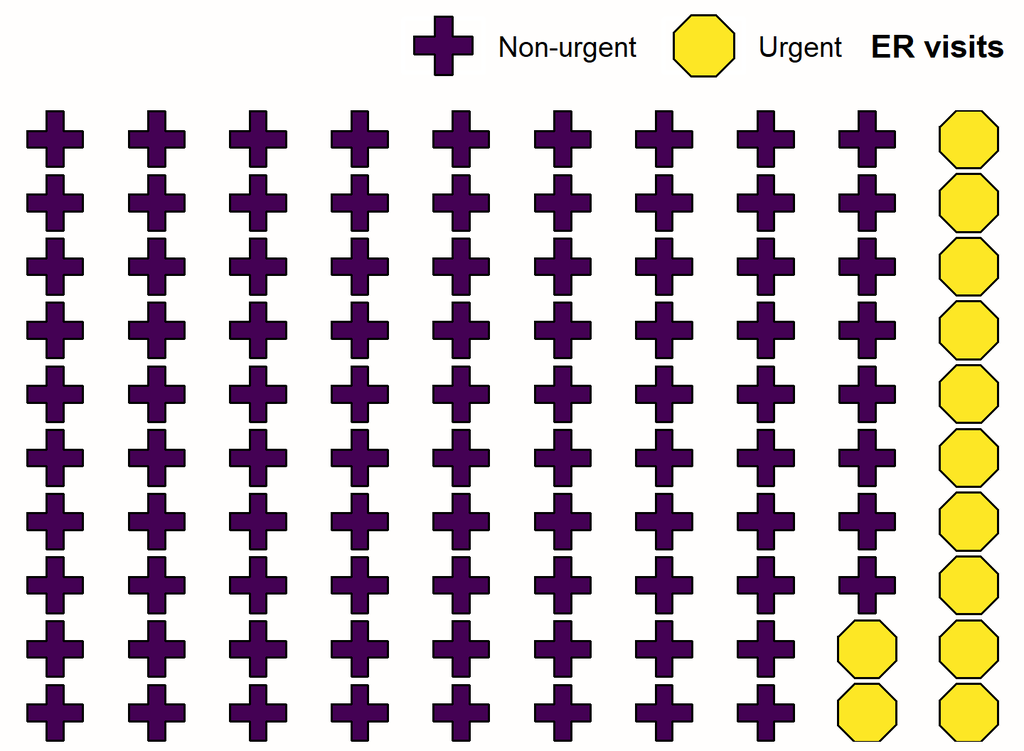

In an icon array, a rectangular grid of icons is used to represent frequency data pictorially. This type of representation has been shown to meaningfully increase the speed and accuracy with which readers can reason about frequencies. These graphs additionally benefit from being very minimal in design by default, so they are often very quick to grasp and also to create.

`ggplotplus` now features `icon_array_plus()`, a quick and easy way to create an icon array using ggplot2 functionality. In fact, the above icon array was produced using `icon_array_plus()`:

```r
er_visits = c(rep("Non-urgent", 88), rep("Urgent", 12))

icon_array_plus(
  vector = er_visits, #<--OBSERVATIONS
  legend_title = "ER visits"
)
```

The function takes as input a vector of observations and converts them to frequencies. It then uses icons to represent these frequencies, with `shape` and `fill` (by default) used to differentiate groups.

The function can handle any number of groups, including missing groups. However, if `max_observed_groups` is exceeded, smaller groups will be consolidated into an “Other” category (missing data are exempt from such consolidation):

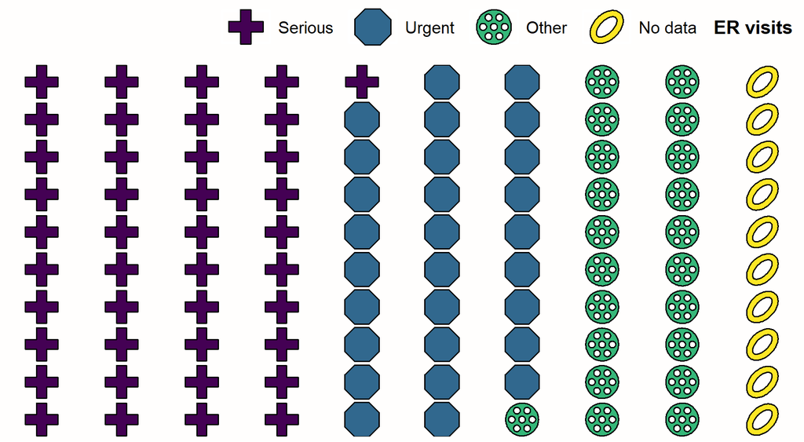

```r
er_visits = c(rep(c("Routine", "Non-Urgent", "Urgent", "Serious", NA), times = c(10, 20, 40, 60, 15)))

icon_array_plus(
  vector = er_visits,
  legend_title = "ER visits",
  max_observed_groups = 3, #<--MAX GROUPS TO MAKE DISTINCT. GROUPS WILL BE CONSOLIDATED TO FIT BENEATH THIS LIMIT AS NEEDED.
  na_label = "No data", #<--LABEL FOR MISSING DATA GROUP
  other_label = "Other" #<--LABEL FOR CONSOLIDATED GROUP.
)
```

The function allows for some customization, including in shapes used for icons, their size, and how they are sorted, as well as in the labeling of the legend:

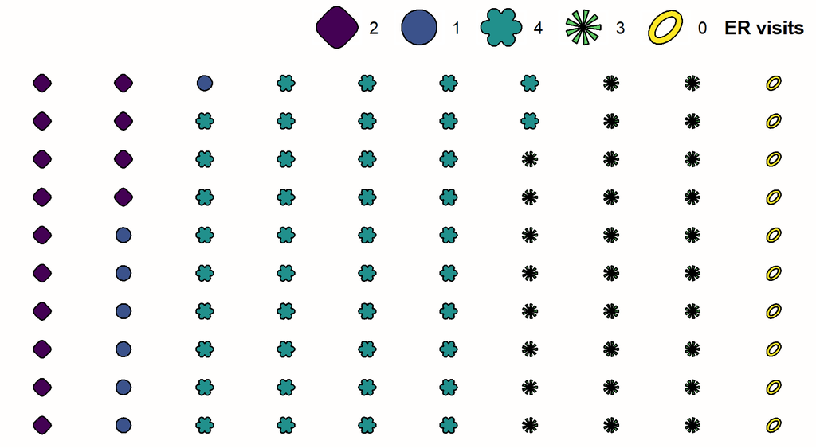

```r
er_visits = c(rep(c("Routine", "Non-Urgent", "Urgent", "Serious", NA), times = c(10, 20, 40, 60, 15)))

icon_array_plus(
  vector = er_visits,
  legend_title = "ER visits",
  na_label = "No data",
  legend_labels = c("Routine" = "1", "Non-Urgent" = "2", "Urgent" = "3", "Serious" = "4", "No data" = "0"), #<--NEW LABELS FOR GROUPS. OLD = NEW FORMAT. NAMED VECTORS WORK BEST.
  icon_size = 4, #<--SMALLER ICONS
  chosen_icon_shapes = c("squircle", "circle", "flower", "sunburst", "oval"), #<--CUSTOM SHAPES FROM THE ggplotplus PALETTE.
  sort_descending = FALSE #<--DON'T SORT LEFT TO RIGHT.
)
```

A true icon array can feature icons of any kind to make group membership maximally intuitive and memorable. In that spirit, you can use `add_shape_plus()` to register new shapes to use within `icon_array_plus()`:

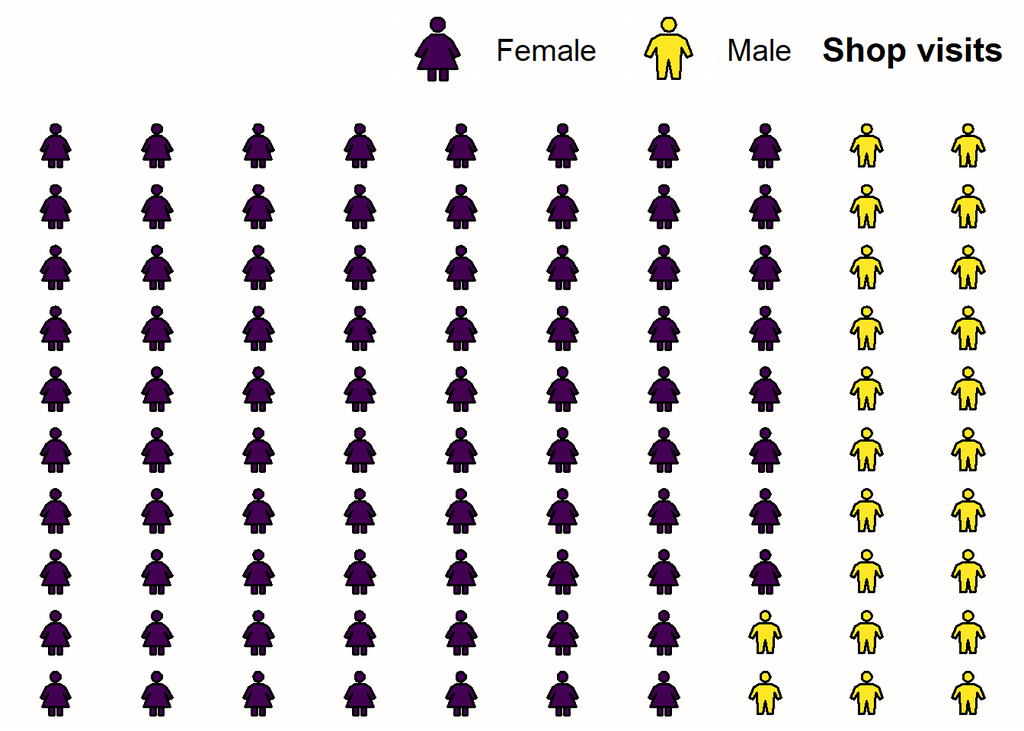

```r
##CODE TO MAKE MALE AND FEMALE SILHOUETTES VIA "CONNECT THE DOTS"
head_angles = seq(0, 2 * pi, length.out = 33)[-33]

silhouette_head = data.frame(
  x = 0.09 * cos(head_angles),
  y = 0.31 + 0.09 * sin(head_angles),
  piece = 1
)

male_body = data.frame(
  x = c(-0.11, -0.22, -0.30, -0.23, -0.16, -0.14, -0.04,
         0.00,  0.04,  0.14,  0.16,  0.23,  0.30,  0.22,  0.11),
  y = c( 0.18,  0.12, -0.08, -0.11,  0.02, -0.38, -0.38,
        -0.14, -0.38, -0.38,  0.02, -0.11, -0.08,  0.12,  0.18),
  piece = 2
)

male_silhouette = rbind(silhouette_head, male_body)

female_body = data.frame(
  x = c(-0.08, -0.18, -0.28, -0.21, -0.14, -0.25,
         0.25,  0.14,  0.21,  0.28,  0.18,  0.08),
  y = c( 0.18,  0.11, -0.08, -0.11,  0.01, -0.25,
        -0.25,  0.01, -0.11, -0.08,  0.11,  0.18),
  piece = 2
)

female_legs = data.frame(
  x = c(-0.12, -0.03, -0.03, -0.12,
         0.03,  0.12,  0.12,  0.03),
  y = c(-0.25, -0.25, -0.40, -0.40,
        -0.25, -0.25, -0.40, -0.40),
  piece = rep(3:4, each = 4)
)

female_silhouette = rbind(silhouette_head, female_body, female_legs)

#REGISTER THESE NEW SHAPES
add_shape_plus(
  "example_male_silhouette",
  male_silhouette,
  overwrite = TRUE
)
add_shape_plus(
  "example_female_silhouette",
  female_silhouette,
  overwrite = TRUE
)

shop_visits = c(rep("Female", 78), rep("Male", 22))

icon_array_plus(
  shop_visits,
  chosen_icon_shapes = c(
    "example_female_silhouette",
    "example_male_silhouette"
  ),
  legend_title = "Shop visits",
  icon_size = 7
)
```

So, if you can dream it, you can make it! It’s relatively easy to have an AI agent design the icons you want to use; Codex from OpenAI was used to draft the silhouettes used above, for example.

Here are a few other technical details to keep in mind about `icon_array_plus()`:

- It calls `ggplot()` internally, so there’s no need to add a `ggplot()` call to your icon array.
- It also calls `theme_plus()` under the hood, using `blank_axes = TRUE` to remove the x and y axes. If you’d like to adjust the theme of your icon array (e.g., to change the `end_discrete` value controlling the colors used), add a `theme_plus()` call to your icon array, **keeping `blank_axes = TRUE`**.
- Many parameters of `geom_point_plus()`, including `data`, `mapping`, `stat`, and others, are disabled via `icon_array_plus()` or have different equivalents. See the documentation for details.
- Although the function can be made to allow it, showing > ~7 groups or > ~100 icons is not generally recommended, as both would tend to exceed the limits of what many can easily and quickly comprehend (although there may be exceptions, such as when a rate of 1/1000 needs to be shown, though you might need to decrease the size of the icons considerably in such cases!).
- When `max_icons` would be exceeded by your raw data, your data are scaled down proportionally to stay at or below `max_icons`, with groups being rounded up to the next full icon only if their remainders would be >= 0.5. In other words, partial icons are not drawn.
- As there are no axes scales, axes titles, or gridlines visible in an icon array, there is no reason to called `yaxis_title_plus()`, `scale_continuous_plus()`, or `gridlines_plus()` with `icon_array_plus()`.

## 16 Exporting Graphs and Resizing

Just as with `ggplot2`, I recommend users use `ggplot2::ggsave()` to export **all** their graphs from R! Using RStudio’s Plots pane to export graphs makes it harder to control the resolution, width, and size of your exported graphs and to ensure consistency from one version of a graph to the next.

Specifically, I highly recommend specifying a `dpi` of at least 300 (the default) to `ggsave()` as well as a `width` and `height` relevant to the intended use of the graph.

For example, full page width in a typical scientific journal is approximately 7 inches, and a typical aspect ratio (width:height) is approximate 1.33, yielding a typical height around 5.26 inches. So, a reasonable `ggsave()` call might look like this:

```r
###HYPOTHETICAL GGSAVE COMMAND
p = ggplot
ggplot2::ggsave(filename = "Myplot.png",
                plot = p,
                dpi = 600,
                width = 7,
                height = 5.26)
```

However, as any experienced `ggplot2` user knows, a graph’s design may look great in RStudio’s Plots pane, when it’s been sized to one set of dimensions, and then may look terrible when it’s saved sized to a different set of dimensions! In particular, font and line width sizes often do not automatically scale well to a range of output dimensions.

`ggplotplus`’s `theme_plus()` function recognizes this and exposes two inputs: `export_width` and `export_height`. When using it, specify the ultimate dimensions you intend to export your graph at (e.g., 7 x 5.26), and it’ll adjust the default font and line sizes (though not any custom sizes you’ve provided!) accordingly to look (reasonably) good at your output dimensions:

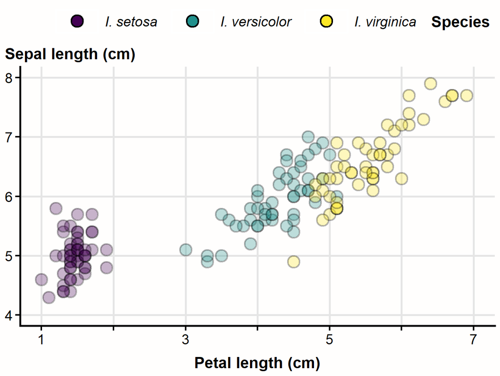

```r
###PLOTTING WINDOW NOW RESCALED TO A WIDTH OF 7 INCHES X 5.26 INCHES

ggplot(iris,
       mapping = aes(x = Petal.Length,
           y = Sepal.Length)) +
  geom_point(mapping = aes(fill = Species),
            alpha = 0.3) +
  scale_continuous_plus(
    scale = "x",
    name = "Petal length (cm)",
    thin.labels = TRUE) +
  scale_continuous_plus(
    scale = "y",
    name = "Sepal length (cm)") +
  scale_fill_discrete(
    labels = c("I. setosa", "I. versicolor", "I. virginica")
  ) +
  theme_plus(
    legend.text = element_text(face = "italic"),
    begin_discrete = 0,
    end_discrete = 1,
    export_width = 7, #<--SET THE OUTPUT WIDTH AND HEIGHT YOU EXPECT AND SIZES OF ELEMENTS WILL ADJUST SOMEWHAT ACCORDINGLY (HERE, A LITTLE SMALLER)
    export_height = 5.26) +
  yaxis_title_plus() +
  gridlines_plus()
```

## 17 Warnings Surrounding Best Practices

While `ggplotplus` goes out of its way to try to align your graphs with data visualization best practices by default, there are certain aspects it cannot necessary coerce for you. However, it can notice when these aspects are suboptimal and gently let you know and give you some ideas for what to do differently.

For example, humans struggle to perceive the differences between colors when there are more than ~7-12 of these within a plot. Beyond this threshold, at least one pair of colors will be difficult for many to tell apart. In the rare instances where so many discrete levels are needed, color is a suboptimal visual channel to use.

If you try to use this many, `ggplotplus` will (politely) recommend different courses of action:

```
Note: Your plot lacks alt text; it's critical for blind and low-vision people, subs in for broken images, and helps search engines find relevant images. Add it via ggplotplus::add_alttext_plus(). Include chart type, variables, and main trends/takeaways.
```

[output not shown]

[output not shown]

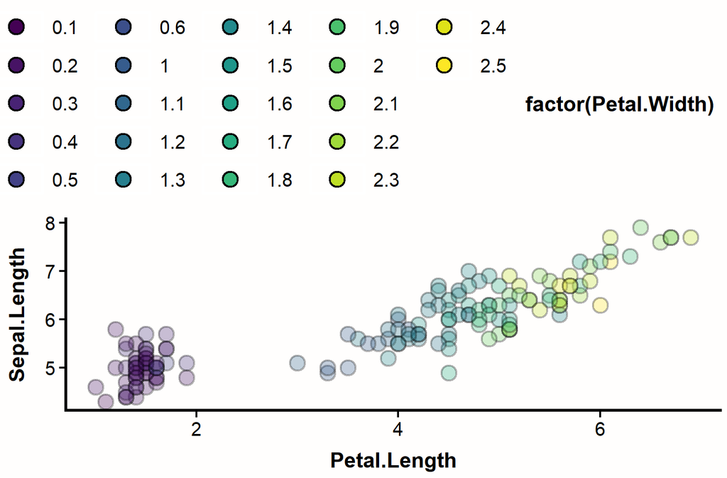

```r
ggplot(data = iris,
       mapping = aes(x = Petal.Length,
           y = Sepal.Length)) +
  geom_point(mapping = aes(
    fill = factor(Petal.Width)), #<--THIS WILL REQUEST A VERY LARGE NUMBER OF DISCRETE COLORS.
             alpha = 0.3) +
  theme_plus(begin_discrete = 0,
              end_discrete = 1)
```

You’ll also note that it encourages you to consider renaming your scale titles to something more informative and human-readable too!

One particular aspect the package’s codebase checks for is **alt** (short for “alternative”) **text**. This text is read aloud to screen reader devices when an image is selected, displays when an image fails to load, and provides search engines with information needed to find relevant images, among other uses.

As such, every graph you make for sharing or publication ought to have alt text. Good alt text indicates the type of chart displayed, the variables plotted, and the key trends/messages of the graph. It needn’t say more than that, though!

Adding alt text to a graph is easy: Use `add_alttext_plus()`:

```r
#HYPOTHETICAL CODE
p = your_ggplot2
p + add_alttext_plus("Scatterplot showing sepal versus petal lengths for three Iris species (setosa, versicolor, and virginica). All three share a nearly 1:1 ratio for these two metrics. Setosa's values are noticably lower than those of the other two species, though.")
```

This function is just a shortcut to `ggplot2`’s `labs(alt = ...)`.

If these coaching messages get too tedious for you, though, you can set `enable_coaching` to FALSE in `yaxis_title_plus()`, `theme_plus()`, or `gridlines_plus()` to turn all these checks and messages off. You can also disable them for the duration of the session by disabling them in the R options via `options(ggplotplus.enable_coaching = FALSE)`.

## 18 Compatibility with other packages

While much probably still needs to be done to make `ggplotplus` easily and fully compatible with the rest of the “ggplot2niverse,” it should be compatible with both `cowplot` and `patchwork`, although its outputs will need to be converted. For example:

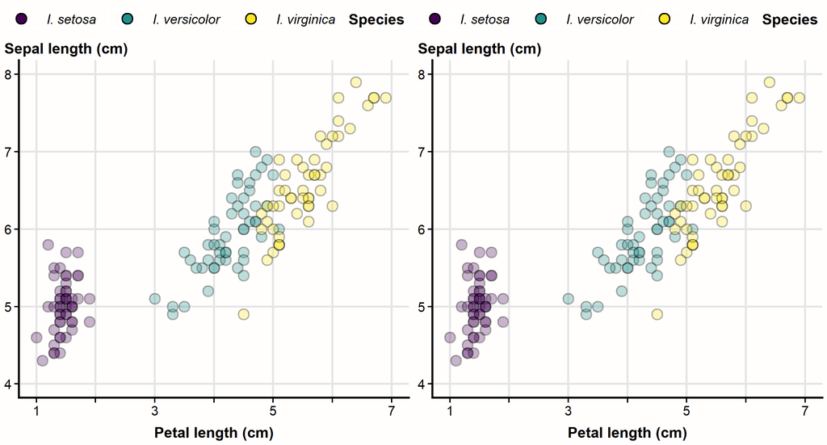

```r
library(cowplot)

P = ggplot(iris, #<--PACK GRAPH INTO OBJECT.
       mapping = aes(x = Petal.Length,
           y = Sepal.Length)) +
  geom_point(mapping = aes(fill = Species),
            alpha = 0.3) +
  scale_continuous_plus(
    scale = "x",
    name = "Petal length (cm)",
    thin.labels = TRUE) +
  scale_continuous_plus(
    scale = "y",
    name = "Sepal length (cm)") +
  scale_fill_discrete(
    labels = c("I. setosa", "I. versicolor", "I. virginica")
  ) +
  theme_plus(
    legend.text = element_text(face = "italic"),
    begin_discrete = 0,
    end_discrete = 1,
    enable_coaching = F) +
  yaxis_title_plus() +
  gridlines_plus()

cowplot::plot_grid(
  ggplotplus_to_cowplot(P), #<--USE ggplotplus_to_cowplot ON THE PACKED OBJECT.
  ggplotplus_to_cowplot(P)
)
```

A similar workflow is available for `patchwork`:

[figure not shown]

```r
library(patchwork)

P = ggplot(iris, #<--PACK GRAPH INTO OBJECT.
       mapping = aes(x = Petal.Length,
           y = Sepal.Length)) +
  geom_point(mapping = aes(fill = Species),
            alpha = 0.3) +
  scale_continuous_plus(
    scale = "x",
    name = "Petal length (cm)",
    thin.labels = TRUE) +
  scale_continuous_plus(
    scale = "y",
    name = "Sepal length (cm)") +
  scale_fill_discrete(
    labels = c("I. setosa", "I. versicolor", "I. virginica")
  ) +
  theme_plus(
    legend.text = element_text(face = "italic"),
    begin_discrete = 0,
    end_discrete = 1,
    enable_coaching = F) +
  yaxis_title_plus() +
  gridlines_plus()

(ggplotplus_to_patchwork(P) | #<--USE ggplotplus_to_patchwork() ON PACKED OBJECT.
   ggplotplus_to_patchwork(P)) +
   patchwork::plot_annotation(
     title = "ggplotplus + patchwork"
   )
```

If you encounter a compatibility issue with another package you depend on, please file an issue on the package’s Github repository!